# DM_Project

Thien Nguyen & Nam Tran

11/20/2021

```r
Insurance_df <- read.csv("Marketing_Customer_Lifetime_Value_Data.csv")
```

```r
dim(Insurance_df)
```

```
## [1] 9134   24
```

```r
head(Insurance_df)
```

```
##   Customer      State Customer.Lifetime.Value Response Coverage Education
## 1  BU79786 Washington                2763.519       No    Basic  Bachelor
## 2  QZ44356    Arizona                6979.536       No Extended  Bachelor
## 3  AI49188     Nevada               12887.432       No  Premium  Bachelor
## 4  WW63253 California                7645.862       No    Basic  Bachelor
## 5  HB64268 Washington                2813.693       No    Basic  Bachelor
## 6  OC83172     Oregon                8256.298      Yes    Basic  Bachelor
##   Effective.To.Date EmploymentStatus Gender Income Location.Code Marital.Status
## 1         2/24/2011         Employed      F  56274      Suburban        Married
## 2         1/31/2011       Unemployed      F      0      Suburban         Single
## 3         2/19/2011         Employed      F  48767      Suburban        Married
## 4         1/20/2011       Unemployed      M      0      Suburban        Married
## 5          2/3/2011         Employed      M  43836         Rural         Single
## 6         1/25/2011         Employed      F  62902         Rural        Married
##   Monthly.Premium.Auto Months.Since.Last.Claim Months.Since.Policy.Inception
```

[output cut: 20 more lines]

This dataset has 9134 observations and 24 variables.

```r
colnames(Insurance_df)
```

```
##  [1] "Customer"                      "State"
##  [3] "Customer.Lifetime.Value"       "Response"
##  [5] "Coverage"                      "Education"
##  [7] "Effective.To.Date"             "EmploymentStatus"
##  [9] "Gender"                        "Income"
## [11] "Location.Code"                 "Marital.Status"
## [13] "Monthly.Premium.Auto"          "Months.Since.Last.Claim"
## [15] "Months.Since.Policy.Inception" "Number.of.Open.Complaints"
## [17] "Number.of.Policies"            "Policy.Type"
## [19] "Policy"                        "Renew.Offer.Type"
## [21] "Sales.Channel"                 "Total.Claim.Amount"
## [23] "Vehicle.Class"                 "Vehicle.Size"
```

```r
str(Insurance_df)
```

```
## 'data.frame':    9134 obs. of  24 variables:
##  $ Customer                     : chr  "BU79786" "QZ44356" "AI49188" "WW63253" ...
##  $ State                        : chr  "Washington" "Arizona" "Nevada" "California" ...
##  $ Customer.Lifetime.Value      : num  2764 6980 12887 7646 2814 ...
##  $ Response                     : chr  "No" "No" "No" "No" ...
##  $ Coverage                     : chr  "Basic" "Extended" "Premium" "Basic" ...
##  $ Education                    : chr  "Bachelor" "Bachelor" "Bachelor" "Bachelor" ...
##  $ Effective.To.Date            : chr  "2/24/2011" "1/31/2011" "2/19/2011" "1/20/2011" ...
##  $ EmploymentStatus             : chr  "Employed" "Unemployed" "Employed" "Unemployed" ...
##  $ Gender                       : chr  "F" "F" "F" "M" ...
##  $ Income                       : int  56274 0 48767 0 43836 62902 55350 0 14072 28812 ...
##  $ Location.Code                : chr  "Suburban" "Suburban" "Suburban" "Suburban" ...
##  $ Marital.Status               : chr  "Married" "Single" "Married" "Married" ...
##  $ Monthly.Premium.Auto         : int  69 94 108 106 73 69 67 101 71 93 ...
##  $ Months.Since.Last.Claim      : int  32 13 18 18 12 14 0 0 13 17 ...
##  $ Months.Since.Policy.Inception: int  5 42 38 65 44 94 13 68 3 7 ...
##  $ Number.of.Open.Complaints    : int  0 0 0 0 0 0 0 0 0 0 ...
##  $ Number.of.Policies           : int  1 8 2 7 1 2 9 4 2 8 ...
##  $ Policy.Type                  : chr  "Corporate Auto" "Personal Auto" "Personal Auto" "Corporate Auto" ...
##  $ Policy                       : chr  "Corporate L3" "Personal L3" "Personal L3" "Corporate L2" ...
##  $ Renew.Offer.Type             : chr  "Offer1" "Offer3" "Offer1" "Offer1" ...
##  $ Sales.Channel                : chr  "Agent" "Agent" "Agent" "Call Center" ...
##  $ Total.Claim.Amount           : num  385 1131 566 530 138 ...
##  $ Vehicle.Class                : chr  "Two-Door Car" "Four-Door Car" "Two-Door Car" "SUV" ...
##  $ Vehicle.Size                 : chr  "Medsize" "Medsize" "Medsize" "Medsize" ...
```

#### Data type:

- Customer : Character / Nominal Variable
- State: Character / Nominal Variable
- Customer.Lifetime.Value : numeric / Numerical Variable
- Response : Character / Binary Variable
- Coverage : Character / Nominal Variable
- Education : Character / Nominal Variable
- Effective.To.Date : Character / Nominal Variable
- EmploymentStatus : Character / Nominal Variable
- Gender : Character / Binary Variable
- Income : Integer / Numerical Variable
- Location.Code : Character / Nominal Variable
- Marital.Status : Character / Nominal Variable
- Monthly.Premium.Auto : Integer / Numerical Variable
- Months.Since.Last.Claim : Integer / Numerical Variable
- Months.Since.Policy.Inception: Integer / Numerical Variable
- Number.of.Open.Complaints : Integer / Numerical Variable
- Number.of.Policies : Integer / Numerical Variable
- Policy.Type : Character / Nominal Variable
- Policy : Character / Nominal Variable
- Renew.Offer.Type : Character / Nominal Variable
- Sales.Channel : Character / Nominal Variable
- Total.Claim.Amount : numeric / Numerical Variable
- Vehicle.Class : Character / Nominal Variable
- Vehicle.Size : Character / Nominal Variable

We do NOT need to examine **“Customer” variable** (Customer ID) and **“Effective.To.Date” variable** (Daytime), because they are irrelevant with our models. We can also remove **Policy** because the Policy.Type variable has similar values with Policy variable

```r
num.val.name <- c("Customer.Lifetime.Value", "Income", "Monthly.Premium.Auto", "Months.Since.Last.Claim", "Months.Since.Policy.Inception", "Number.of.Open.Complaints",
                  "Number.of.Policies", "Total.Claim.Amount")
cat.val.name <- c("State", "Response", "Coverage", "Education", "EmploymentStatus", "Gender", "Location.Code", "Marital.Status", "Policy.Type", "Policy",
                  "Renew.Offer.Type", "Sales.Channel", "Vehicle.Class", "Vehicle.Size")
```

### DATA EXPLORATION

We will explore the information to understanding deeply data.

### DEALING WITH MISSING VALUES

```r
# apply(is.na(Insurance_df),2,which): Another way to find the location of missing values
summary(Insurance_df[,cat.val.name])
```

```
##     State             Response           Coverage          Education
##  Length:9134        Length:9134        Length:9134        Length:9134
##  Class :character   Class :character   Class :character   Class :character
##  Mode  :character   Mode  :character   Mode  :character   Mode  :character
##  EmploymentStatus      Gender          Location.Code      Marital.Status
##  Length:9134        Length:9134        Length:9134        Length:9134
##  Class :character   Class :character   Class :character   Class :character
##  Mode  :character   Mode  :character   Mode  :character   Mode  :character
##  Policy.Type           Policy          Renew.Offer.Type   Sales.Channel
##  Length:9134        Length:9134        Length:9134        Length:9134
##  Class :character   Class :character   Class :character   Class :character
##  Mode  :character   Mode  :character   Mode  :character   Mode  :character
##  Vehicle.Class      Vehicle.Size
##  Length:9134        Length:9134
##  Class :character   Class :character
##  Mode  :character   Mode  :character
```

```r
# Fortunately, There is NO MISSING VALUE in Categorical Variables.
summary(Insurance_df[,num.val.name])
```

```
##  Customer.Lifetime.Value     Income      Monthly.Premium.Auto
##  Min.   : 1898           Min.   :    0   Min.   : 61.00
##  1st Qu.: 3994           1st Qu.:    0   1st Qu.: 68.00
##  Median : 5780           Median :33890   Median : 83.00
##  Mean   : 8005           Mean   :37657   Mean   : 93.22
##  3rd Qu.: 8962           3rd Qu.:62320   3rd Qu.:109.00
##  Max.   :83325           Max.   :99981   Max.   :298.00
##  Months.Since.Last.Claim Months.Since.Policy.Inception
##  Min.   : 0.0            Min.   : 0.00
##  1st Qu.: 6.0            1st Qu.:24.00
##  Median :14.0            Median :48.00
##  Mean   :15.1            Mean   :48.06
##  3rd Qu.:23.0            3rd Qu.:71.00
##  Max.   :35.0            Max.   :99.00
##  Number.of.Open.Complaints Number.of.Policies Total.Claim.Amount
##  Min.   :0.0000            Min.   :1.000      Min.   :   0.099
##  1st Qu.:0.0000            1st Qu.:1.000      1st Qu.: 272.258
##  Median :0.0000            Median :2.000      Median : 383.945
##  Mean   :0.3844            Mean   :2.966      Mean   : 434.089
##  3rd Qu.:0.0000            3rd Qu.:4.000      3rd Qu.: 547.515
##  Max.   :5.0000            Max.   :9.000      Max.   :2893.240
```

```r
# Numerical Variables do not have missing values as well.
```

### SUMMARY STATISTICS AND DEALING WITH OUTLIERS.

### NUMERICAL VARIABLES

```r
num.sum.stat <- skimr::skim(Insurance_df[,num.val.name])
num.sum.stat
```

Data summary

| Name | Insurance_df[, num.val.na… |
| --- | --- |
| Number of rows | 9134 |
| Number of columns | 8 |
| _______________________ |  |
| Column type frequency: |  |
| numeric | 8 |
| ________________________ |  |
| Group variables | None |

**Variable type: numeric**

| skim_variable | n_missing | complete_rate | mean | sd | p0 | p25 | p50 | p75 | p100 | hist |
| --- | --- | --- | --- | --- | --- | --- | --- | --- | --- | --- |
| Customer.Lifetime.Value | 0 | 1 | 8004.94 | 6870.97 | 1898.01 | 3994.25 | 5780.18 | 8962.17 | 83325.38 | ▇▁▁▁▁ |
| Income | 0 | 1 | 37657.38 | 30379.90 | 0.00 | 0.00 | 33889.50 | 62320.00 | 99981.00 | ▇▆▅▅▃ |
| Monthly.Premium.Auto | 0 | 1 | 93.22 | 34.41 | 61.00 | 68.00 | 83.00 | 109.00 | 298.00 | ▇▂▁▁▁ |
| Months.Since.Last.Claim | 0 | 1 | 15.10 | 10.07 | 0.00 | 6.00 | 14.00 | 23.00 | 35.00 | ▇▆▅▅▃ |
| Months.Since.Policy.Inception | 0 | 1 | 48.06 | 27.91 | 0.00 | 24.00 | 48.00 | 71.00 | 99.00 | ▇▇▇▇▆ |
| Number.of.Open.Complaints | 0 | 1 | 0.38 | 0.91 | 0.00 | 0.00 | 0.00 | 0.00 | 5.00 | ▇▁▁▁▁ |
| Number.of.Policies | 0 | 1 | 2.97 | 2.39 | 1.00 | 1.00 | 2.00 | 4.00 | 9.00 | ▇▂▁▁▁ |
| Total.Claim.Amount | 0 | 1 | 434.09 | 290.50 | 0.10 | 272.26 | 383.95 | 547.51 | 2893.24 | ▇▂▁▁▁ |

Let examine into each variable:

### Customer Lifetime Value:

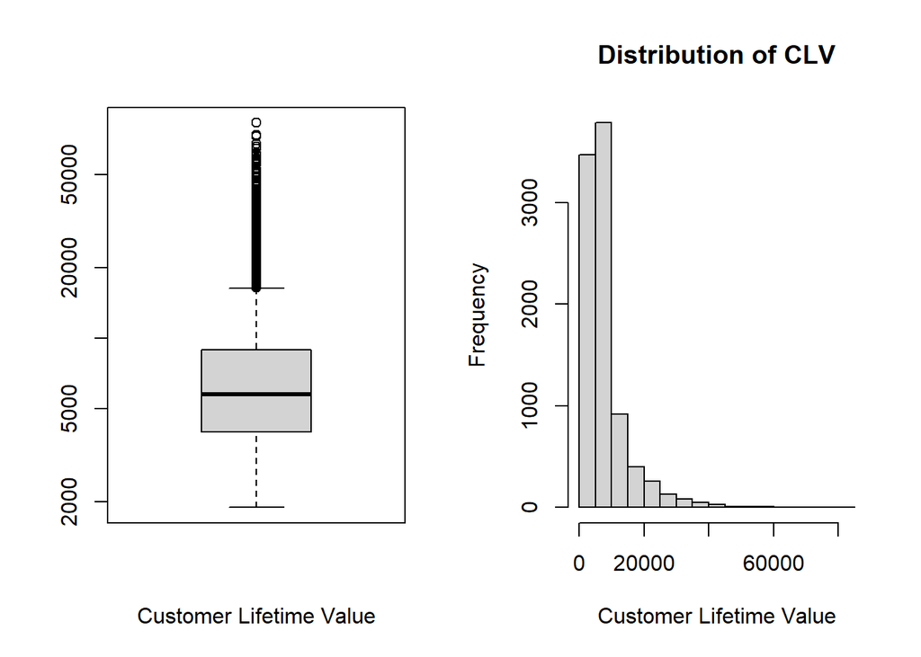

```r
par(mfrow = c(1,2))
boxplot(Insurance_df$Customer.Lifetime.Value, xlab = "Customer Lifetime Value", log = 'y')
hist(Insurance_df$Customer.Lifetime.Value, xlab = "Customer Lifetime Value", main = "Distribution of CLV")
```

```r
nrow(Insurance_df[Insurance_df$Customer.Lifetime.Value > 20000,])/length(Insurance_df$Customer.Lifetime.Value)*100
```

```
## [1] 6.295161
```

```r
# Customer Lifetime Value is the outcome variable:
# Max: $83325/ Min: $1898/ Mean: $8005/ sd: $6871
# From the boxplot and histogram, the distribution of Customer.Lifetime.Value is right skewed.
# Most of customer lifetime value is less than 20000
# But we have 6% (575) records that have value far greater than the mean, We need to consider these values carefully later because they are the most value customers.
```

### Income

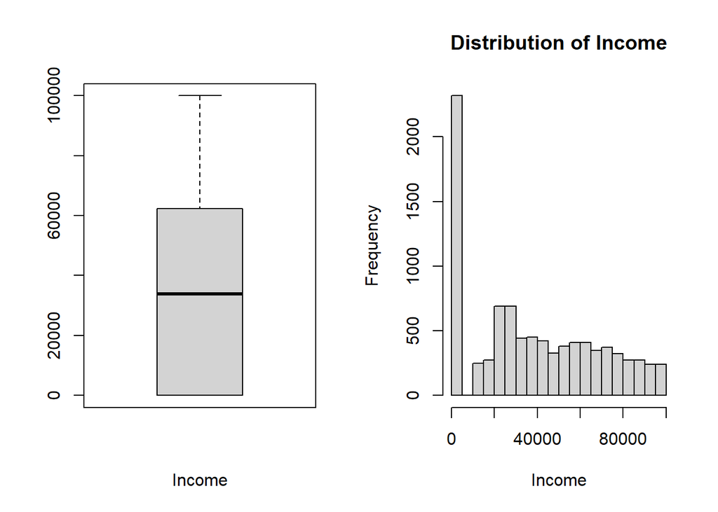

```r
par(mfrow = c(1,2))
boxplot(Insurance_df$Income, xlab = "Income")
hist(Insurance_df$Income, xlab = "Income", main = "Distribution of Income")
```

```r
# Max: $99981/ Min: $0/ Mean: $37657/ sd: $30380
# From histogram, except 0 values of income, the income varies from $10000 to $100000.
```

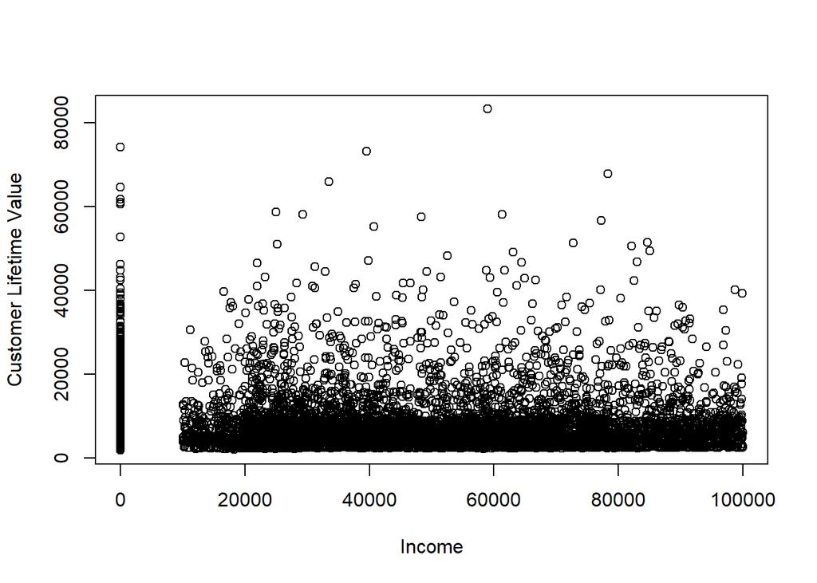

```r
plot(Insurance_df$Customer.Lifetime.Value ~ Insurance_df$Income, xlab = "Income", ylab = "Customer Lifetime Value")
```

The plot shows there is barely relationship between Income and Customer Value.

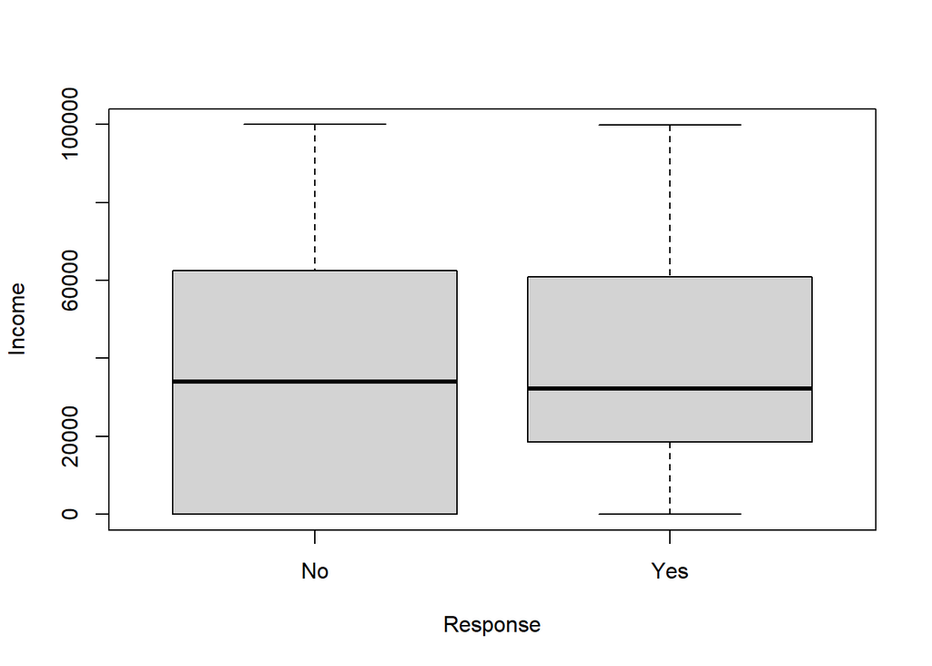

```r
boxplot(Insurance_df$Income ~ Insurance_df$Response, xlab = "Response", ylab = "Income")
```

Customers who deny renewal offer have wider range of income than customer accept the offer.